# CS 329E Data Visualization - Project 1

**For this project, we explore the different capabilities of the R programming language in terms of plotting data from different data frames. We extract data from the OracleCloud and produce publication-quality plots to demonstrate various different graphing techniques.**

**Authors: Bruno De Hoyos, Estevan Garza (eg22453)**

### Importing data frames:

We begin by importing some useful libraries:

```r
source("../01 Data/LibrarySetup.R", echo=TRUE, max.deparse.length=1e3)
```

```
##
## > library("ggplot2", lib.loc = "/Library/Frameworks/R.framework/Versions/3.1/Resources/library")
##
## > library("grid", lib.loc = "/Library/Frameworks/R.framework/Versions/3.1/Resources/library")
##
## > library("plyr", lib.loc = "/Library/Frameworks/R.framework/Versions/3.1/Resources/library")
##
## > library("reshape2", lib.loc = "/Library/Frameworks/R.framework/Versions/3.1/Resources/library")
##
## > library("RCurl", lib.loc = "/Library/Frameworks/R.framework/Versions/3.1/Resources/library")
```

```
##
## > library("gplots", lib.loc = "/Library/Frameworks/R.framework/Versions/3.1/Resources/library")
```

We now begin building our data frames. We build the data frames through the data.frame() function, and passing to it a URL to an OracleCloud server with an appropriate SQL query.

```r
source("../01 Data/DataFrameCode.R", echo = TRUE, max.deparse.length=1e3)
```

```
##
## > df_c <- data.frame(eval(parse(text = substring(getURL(URLencode("http://129.152.144.84:5001/rest/native/?query=\"select * from customers\""),
## +     httpheader = c(DB = "jdbc:oracle:thin:@129.152.144.84:1521/PDB1.usuniversi01134.oraclecloud.internal",
## +         USER = "DV_ORDERS", PASS = "orcl", MODE = "native_mode",
## +         MODEL = "model", returnFor = "R", returnDimensions = "False"),
## +     verbose = TRUE), 1, 2^31 - 1))))
##
## > df_i <- data.frame(eval(parse(text = substring(getURL(URLencode("http://129.152.144.84:5001/rest/native/?query=\"select * from items\""),
## +     httpheader = c(DB = "jdbc:oracle:thin:@129.152.144.84:1521/PDB1.usuniversi01134.oraclecloud.internal",
## +         USER = "DV_ORDERS", PASS = "orcl", MODE = "native_mode",
## +         MODEL = "model", returnFor = "R", returnDimensions = "False"),
## +     verbose = TRUE), 1, 2^31 - 1))))
##
## > df_o <- data.frame(eval(parse(text = substring(getURL(URLencode("http://129.152.144.84:5001/rest/native/?query=\"select * from orders\""),
## +     httpheader = c(DB = "jdbc:oracle:thin:@129.152.144.84:1521/PDB1.usuniversi01134.oraclecloud.internal",
## +         USER = "DV_ORDERS", PASS = "orcl", MODE = "native_mode",
## +         MODEL = "model", returnFor = "R", returnDimensions = "False"),
## +     verbose = TRUE), 1, 2^31 - 1))))
##
## > df_od <- data.frame(eval(parse(text = substring(getURL(URLencode("http://129.152.144.84:5001/rest/native/?query=\"select * from order_details\""),
## +     httpheader = c(DB = "jdbc:oracle:thin:@129.152.144.84:1521/PDB1.usuniversi01134.oraclecloud.internal",
## +         USER = "DV_ORDERS", PASS = "orcl", MODE = "native_mode",
## +         MODEL = "model", returnFor = "R", returnDimensions = "False"),
## +     verbose = TRUE), 1, 2^31 - 1))))
```

We print out the data frames using the head() function to ensure that they all contain data and no errors were encountered while fetching the data.

```r
source("../01 Data/DataFrameShow.R", echo = TRUE, max.deparse.length=1e3)
```

```
##
## > head(df_c)
##   CUSTOMER_ID CUSTOMER_FIRST_NAME CUSTOMER_LAST_NAME      CUSTOMER_ADDRESS
## 1           1               Korah             Blanca       1555 W Lane Ave
## 2           2                Yash            Randall 11 E Rancho Madera Rd
## 3           3           Johnathon          Millerton        60 Madison Ave
## 4           4             Mikayla             Damion      2021 K Street Nw
## 5           5             Kendall              Mayte 4775 E Miami River Rd
## 6           6             Kaitlin           Hostlery 3250 Spring Grove Ave
##   CUSTOMER_CITY CUSTOMER_STATE CUSTOMER_ZIP CUSTOMER_PHONE CUSTOMER_FAX
## 1      Columbus             OH        43221     6145554432   6145553920
## 2       Madison             WI        53707     2095551205   2095552262
## 3      New York             NY        10010     2125554800         NULL
## 4    Washington             DC        20006     2025555561         NULL
## 5        Cleves             OH        45002     5135553024         NULL
```

[output cut: 35 more lines]

### Visualizing the data:

```
##
## > ggplot(df_c, aes(x = CUSTOMER_STATE)) + geom_histogram()
```

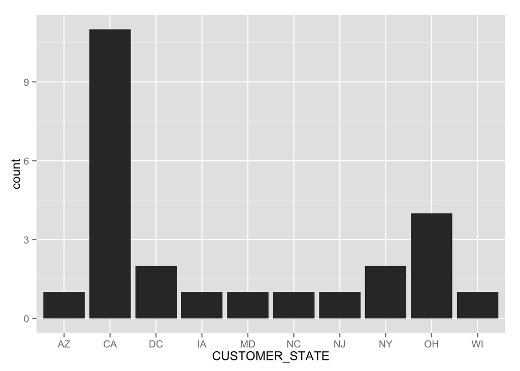

```
##
## > ggplot(df_i, aes(x = ARTIST, y = UNIT_PRICE)) + geom_point()
```

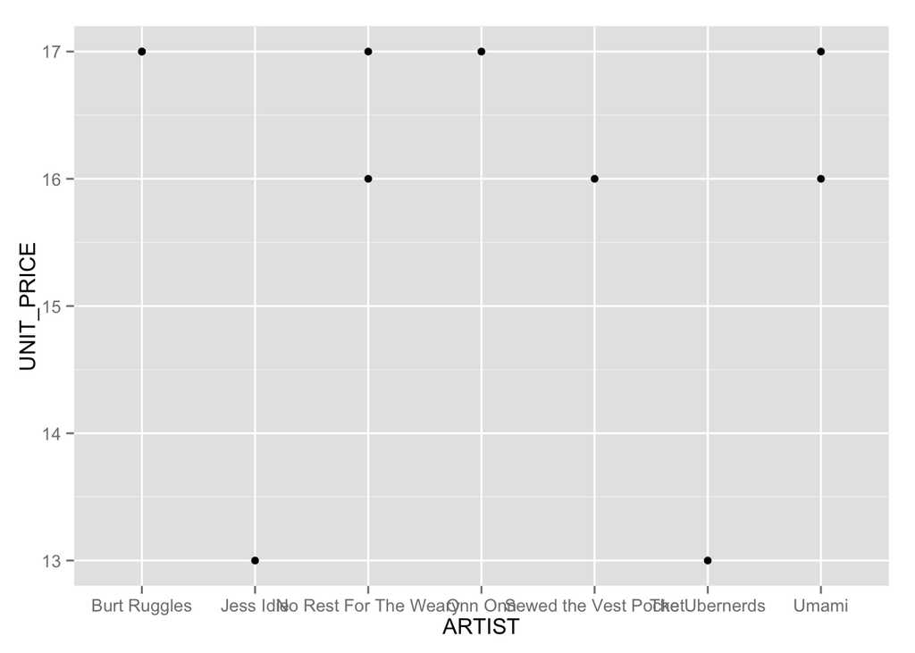

```
##
## > ggplot(df_o, aes(x = CUSTOMER_ID)) + geom_histogram(binwidth = 1)
```

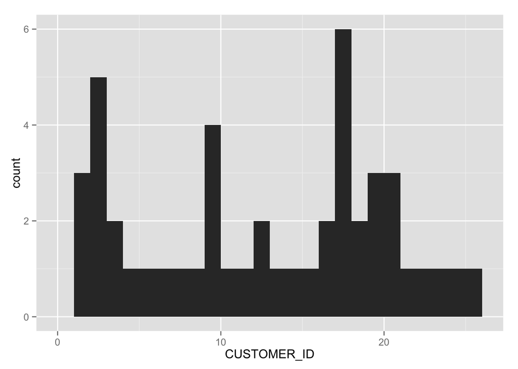

```
##
## > ggplot(df_od, aes(x = ORDER_ID)) + geom_histogram(binwidth = 10)
```

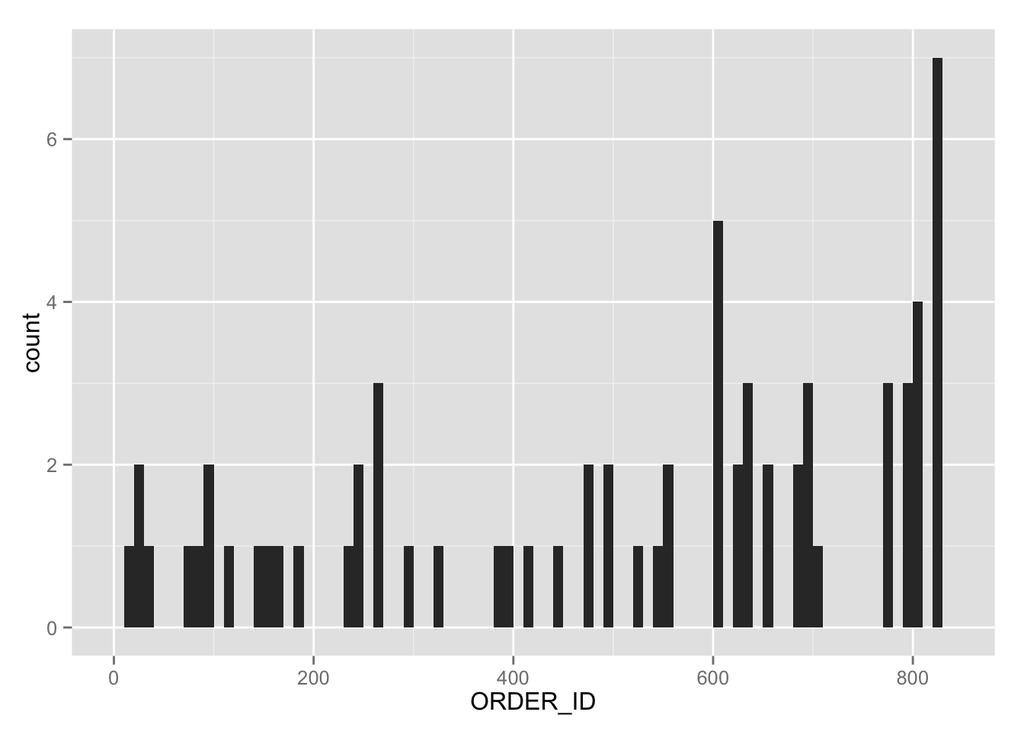

```r
source("../02 Visualizations/Plot1.R", echo = TRUE, max.deparse.length=1e3)
```

By studying these plots, we can get some meaningful and interesting information from them.

The second plot is a point plot showing the unit price of an album for various artists. Althought we can immediately see that the music albums range in price from $13 to $17, we are able to see a clear division of prices between ‘expensive’ artists and ‘inexpensive’ artists. This division may be an indication to the quality of the music.

For the third plot, we made a histogram showing the number of orders a specific customer made throughout the data collection period. We can see that there is a large majority of customers who only make a single order, and a couple of outliers who made 4 or more orders.

Finally, for the fourth plot, we made another histogram showing the number of items in each of the orders in our data. Again, we see that most orders are composed of a single item, with a few outlier orders which had significantly more items than the average.

### Combining the data:

Now that we have a sense of what our data looks like, we are ready to combine all of the data frames into a single, large data frame. We do this through the following command, and calling head() afterwards to ensure that the data was stored in the data frame:

```r
source("../01 Data/DataFrameCode2.R", echo = TRUE, max.deparse.length=1e3)
```

```
##
## > df_all <- data.frame(eval(parse(text = substring(getURL(URLencode("http://129.152.144.84:5001/rest/native/?query=\"select * from orders o join customers c on o.customer_id = c.customer_id join order_details d on o.order_id = d.order_id join items i on d.item_id = i.item_id\""),
## +     httpheader = c(DB = "jdbc:oracle:thin:@129.152.144.84:1521/PDB1.usuniversi01134.oraclecloud.internal",
## +         USER = "DV_ORDERS", PASS = "orcl", MODE = "native_mode",
## +         MODEL = "model", returnFor = "R", returnDimensions = "False"),
## +     verbose = TRUE), 1, 2^31 - 1))))
##
## > head(df_all)
##   ORDER_ID CUSTOMER_ID          ORDER_DATE        SHIPPED_DATE
## 1      550          17 2014-03-23 00:00:00 2014-04-03 00:00:00
## 2      298          18 2013-08-18 00:00:00 2013-09-22 00:00:00
## 3      242          23 2013-06-24 00:00:00 2013-07-06 00:00:00
## 4      829           9 2014-08-02 00:00:00                null
## 5       70          10 2012-12-28 00:00:00 2013-01-07 00:00:00
## 6      800          19 2014-07-21 00:00:00 2014-07-28 00:00:00
##   CUSTOMER_ID.1 CUSTOMER_FIRST_NAME CUSTOMER_LAST_NAME
## 1            17              Samuel           Jacobsen
## 2            18              Justin              Javen
## 3            23              Trisha               Anum
## 4             9              Karina               Lacy
## 5            10                Kurt           Nickalus
## 6            19                Kyle            Marissa
##          CUSTOMER_ADDRESS    CUSTOMER_CITY CUSTOMER_STATE CUSTOMER_ZIP
## 1       3433 E Widget Ave        Palo Alto             CA        92711
## 2          828 S Broadway        Tarrytown             NY        10591
## 3        627 Aviation Way Manhatttan Beach             CA        90266
## 4         882 W Easton Wy      Los Angeles             CA        90084
## 5 28210 N Avenue Stanford         Valencia             CA        91355
## 6         789 E Mercy Ave          Phoenix             AZ        85038
##   CUSTOMER_PHONE CUSTOMER_FAX ORDER_ID.1 ITEM_ID ORDER_QTY ITEM_ID.1
## 1     4155553536         NULL        550       1         1         1
## 2     8005550080         NULL        298       1         1         1
## 3     3105552640         NULL        242       1         1         1
## 4     8005557248         NULL        829       1         1         1
## 5     8055550464   8055556608         70       1         1         1
## 6     9475554304         NULL        800       1         1         1
##              TITLE ARTIST UNIT_PRICE
## 1 Umami In Concert  Umami         17
## 2 Umami In Concert  Umami         17
## 3 Umami In Concert  Umami         17
## 4 Umami In Concert  Umami         17
## 5 Umami In Concert  Umami         17
## 6 Umami In Concert  Umami         17
```

With the large data frame loaded into R, we are now able to make some complex and interesting plots using a variety of the data columns as inputs to our plots. The following commands illustrates how to achieve these plots:

```
##
## > ggplot(df_all, aes(x = as.Date(ORDER_DATE, "%Y-%m-%d"),
## +     y = as.Date(SHIPPED_DATE, "%Y-%m-%d"))) + geom_point(aes(color = as.factor(UNIT_PRICE))) +
## +     facet_wrap(~CUSTOMER_STATE)
```

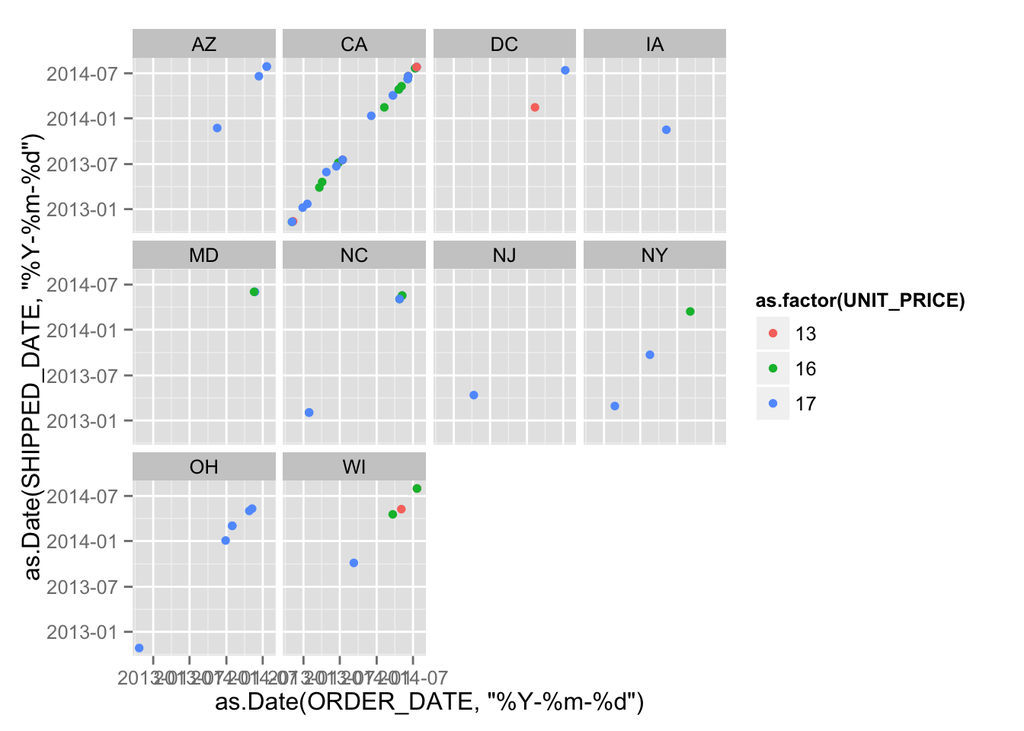

```
##
## > ggplot(df_all, aes(x = as.Date(ORDER_DATE, "%Y-%m-%d"),
## +     y = as.Date(SHIPPED_DATE, "%Y-%m-%d"))) + geom_point(aes(color = as.factor(TITLE))) +
## +     facet_wrap(~CUSTOMER_STATE)
```

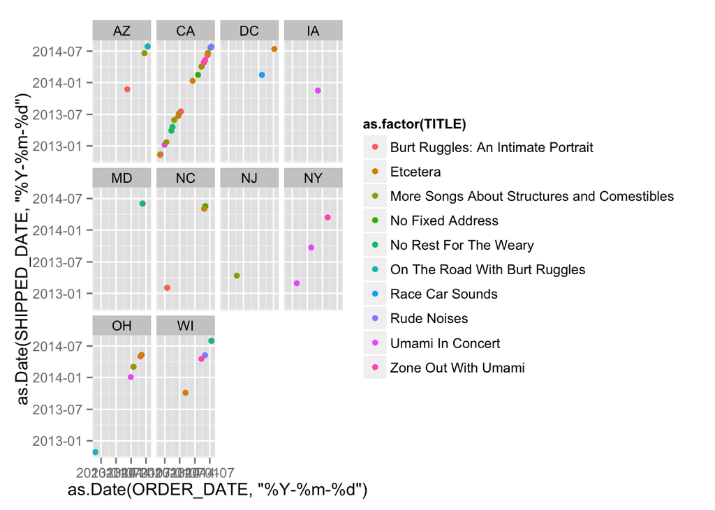

```
##
## > ggplot(df_all, aes(x = as.Date(ORDER_DATE, "%Y-%m-%d"),
## +     y = as.Date(SHIPPED_DATE, "%Y-%m-%d"))) + geom_point(aes(color = as.factor(ARTIST))) +
## +     facet_wrap(~CUSTOMER_STATE)
```

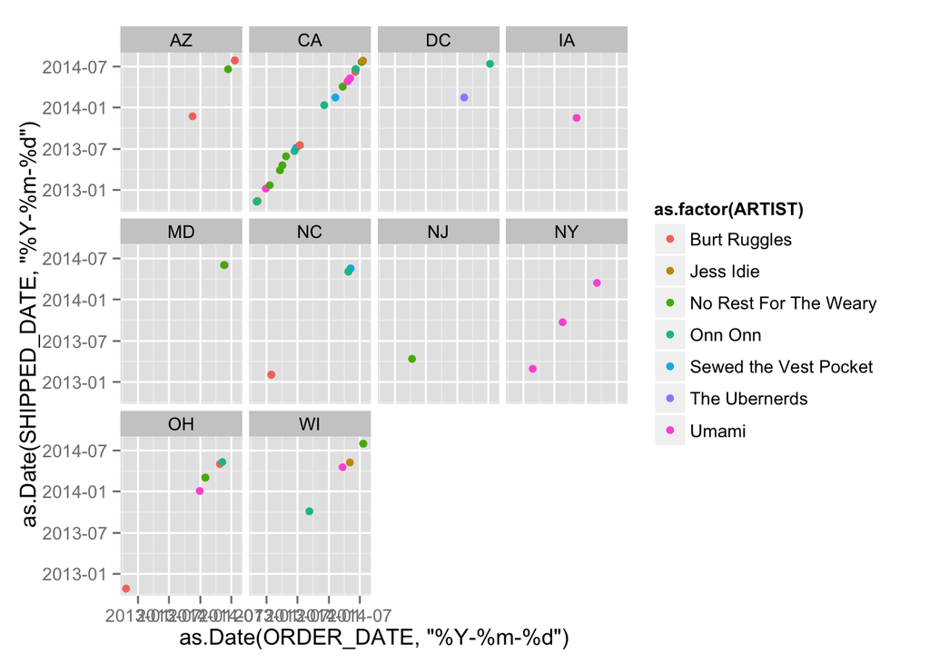

```r
source("../02 Visualizations/Plot2.R", echo = TRUE, max.deparse.length=1e3)
```